# newliks

Let’s simulate data with one covariance matrix, and $\omega$ fixed at 2. We will also use only one $\omega$ in our inference matrices. The purpose of this document was to test the ability of `mash` and `mashnobaseline` to infer the truth when there was only one $\omega$ to complicate things, so that the ‘shrinkage’ was not an issue. You can see the inferred covariance matrices are shorter.

We can have a look at the them first. Here, the c and t should be the same because they are simulated with standard error of 1.

```r
system("ls; rm *rds;rm *txt; rm *pdf")
rm(list=ls())
library('mashr')
set.seed(123)
c=chat_sim_fsingle_fixedomega(n = 1000,d = 8,omega = 2,esd = 1,reals=1)
saveRDS(c,"chatfixedomega.rds")
diag(c$covmat)
```

```
## [1] 0 0 0 0 0 0 1 1
```

And here we run our analysis:

```r
c=readRDS("chatfixedomega.rds")
t=c$t;b=c$chat;se=c$shat
#hist(t)
#hist(b)
R=ncol(t)
L=diag(R)-1/R*as.vector(rep(1,R))%*%t(as.vector(rep(1,R)))
s.j=se/se


###here we cheat and use the index as the 'real associations'

index=which(rowSums(c$beta)!=0)

#index=which(rowMeans(abs(t(L%*%t(c$t))))>1.3)##choose the associations with average deviation large.



sparsestrongt=t(L%*%t(t[index,]))
```

```r
write.table(sparsestrongt,"sparsestrongt.txt",col.names = FALSE,row.names=FALSE)
```

Now, we need to project into the centered space to estimate the covariance matrix of the true deviations, using the full L since $v$ will be R, and not $R-1$.

```r
system('/Users/sarahurbut/miniconda3/bin/sfa -gen sparsestrongt.txt -g 1000 -k 5 -n 8 i -o sparseF')
A="sparseF"

factor.mat=as.matrix(read.table("sparseF_F.out"))
lambda.mat=as.matrix(read.table("sparseF_lambda.out"))

#recall here that w will now be the L[-1,]%*%t(t[strong,]), which is equivalent to removing the first column of the strong projected t. Thus the covariance of v is initated with the RxR matrices (strong projected t), and the model is trained on the strong projected t less the first column because the model has v_{rxr}|w_{r,r-1}

strongprojectedt=sparsestrongt


lvllist=genlvllist(s.j[index,],L = L[-1,])


##w should represent transformed betahats using all R subgroups and j genes
wfull=t(L%*%t(b))
sjmat=convertstandarderrors(s.j = se,L=L)##make this be the standard errors of all, it is the sqrt of the diagonal of LVL' for each j. Recall here L is still RxR so we can have the full set of deviations and thier standard errors to choose grid
dim(wfull)
```

```
## [1] 1000    8
```

```r
dim(sjmat)
```

```
## [1] 1000    8
```

```r
w=data.frame(wfull)[,-1]
```

– Now run with ED to generate the max like covariance matrix using the maximum initialized t statistics and compare to the initial X’X:

```r
A="withoneK"


library("ExtremeDeconvolution")
efunc=deconvolution.em.with.bovy.with.L.oneK(t.stat = strongprojectedt,v.j = lvllist,L = L[-1,],w = strongprojectedt[,-1])

dim(efunc$true.covs)
```

```
## [1] 1 8 8
```

```r
length(efunc$pi)
```

```
## [1] 1
```

```r
#efunc$true.covs[1,,]-min(abs(efunc$true.covs[1,,]))

##compare to initialized matrix
X.real=as.matrix(strongprojectedt)
X.c=apply(X.real,2,function(x) x-mean(x)) ##Column centered matrix of t statistics
data.prox=((t(X.c)%*%X.c))/(nrow(X.real)-1)
(data.prox)-min(abs(data.prox))
```

```
##              [,1]        [,2]        [,3]         [,4]         [,5]
## [1,]  1.029348557 -0.02327078  0.03058908 -0.005288963  0.055267559
## [2,] -0.023270779  0.98846645 -0.02129341 -0.039404746 -0.011460091
## [3,]  0.030589078 -0.02129341  0.96551005  0.018685348 -0.029096651
## [4,] -0.005288963 -0.03940475  0.01868535  0.948613330 -0.002326287
## [5,]  0.055267559 -0.01146009 -0.02909665 -0.002326287  1.004943406
## [6,]  0.015504719  0.01140774 -0.02810613  0.042121115 -0.010587524
## [7,] -0.560338033 -0.47590906 -0.49351407 -0.514656672 -0.520700897
## [8,] -0.551117287 -0.43784124 -0.45207937 -0.457048273 -0.495344662
##             [,6]       [,7]       [,8]
## [1,]  0.01550472 -0.5603380 -0.5511173
## [2,]  0.01140774 -0.4759091 -0.4378412
## [3,] -0.02810613 -0.4935141 -0.4520794
## [4,]  0.04212112 -0.5146567 -0.4570483
## [5,] -0.01058752 -0.5207009 -0.4953447
## [6,]  1.01145948 -0.5179255 -0.5331790
## [7,] -0.51792551  2.0707383  1.0030008
## [8,] -0.53317903  1.0030008  1.9143039
```

Here you can see our ‘list’ of covariance matrices contains just one covariance matrix that has been scaled to contain 2 as the max on the diagonal.

```r
covlist=list();covlist[[1]]=2*efunc$true.covs[1,,]/max(diag(efunc$true.covs[1,,]))
edcov=edcov=covlist
max(edcov[[1]])
```

```
## [1] 2
```

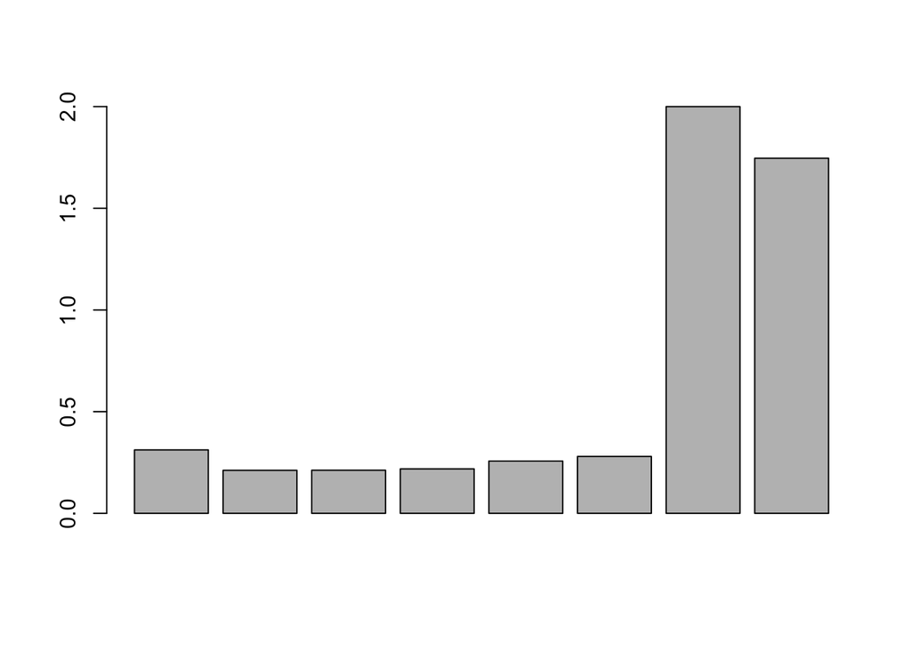

```r
barplot(diag(edcov[[1]]))
```

```r
w=data.frame(wfull)[,-1]

j=1
A="withoneKandoneomeganew"
compute.hm.train.log.lik.pen.with.L(w[index,],se.train = se,covmat = edcov,A = A,pen = 1,L = L[-1,])
```

```r
likmat=t(as.matrix(readRDS(paste0("liketrain",A,".rds"))))

sum(log(exp(likmat)))
```

```
## [1] -9589.471
```

```r
sum(log(exp(likmat[1:1000])))
```

```
## [1] -9589.471
```

```r
LSigL=lapply(edcov,function(x){L[-1,]%*%x%*%t(L[-1,])})

lltest=log.lik.func(b.mle=w[j,],V.gp.hat = L[-1,]%*%diag(se[j,])^2%*%t(L[-1,]),covmat =LSigL )

identical(as.numeric(likmat[j]),as.numeric(lltest))
```

```
## [1] TRUE
```

Let’s try without 2:

```r
covlist=list();covlist[[1]]=efunc$true.covs[1,,]
edcov=edcov=covlist
max(edcov[[1]])
```

```
## [1] 1.21347
```

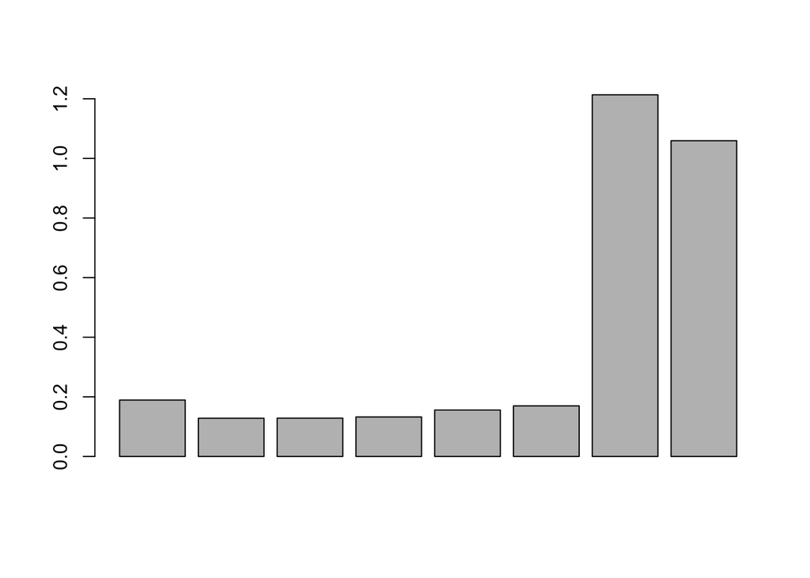

```r
barplot(diag(edcov[[1]]))
```

```r
w=data.frame(wfull)[,-1]
L=diag(R)-1/R*as.vector(rep(1,R))%*%t(as.vector(rep(1,R)))

j=1
A="withoneKandoneomeganewwithnoscale"
compute.hm.train.log.lik.pen.with.L(w[index,],se.train = se,covmat = edcov,A = A,pen = 1,L = L[-1,])
```

```r
likmat=t(as.matrix(readRDS(paste0("liketrain",A,".rds"))))

sum(log(exp(likmat)))
```

```
## [1] -9553.341
```

```r
sum(log(exp(likmat[1:1000])))
```

```
## [1] -9553.341
```

```r
LSigL=lapply(edcov,function(x){L[-1,]%*%x%*%t(L[-1,])})

lltest=log.lik.func(b.mle=w[j,],V.gp.hat = L[-1,]%*%diag(se[j,])^2%*%t(L[-1,]),covmat =LSigL )

identical(as.numeric(likmat[j]),as.numeric(lltest))
```

```
## [1] TRUE
```

```r
pis=1
A="mashnobedcov"
L=diag(R)-1/R*as.vector(rep(1,R))%*%t(as.vector(rep(1,R)))

weightedquants=lapply(seq(1:nrow(w)),function(j){total.quant.per.snp.no.baseline(j,edcov,b.gp.hat=w,se.gp.hat = se,pis,A=A,checkpoint = FALSE,L=L[-1,])})

w=data.frame(wfull[,-1])
a=post.mean.with.proj(b.mle = t(w[1,]),tinv = solve(L[-1,]%*%diag(se[1,],R)%*%t(L[-1,])+L[-1,]%*%edcov[[1]]%*%t(L[-1,])),U.k = edcov[[1]],L=L[-1,])
mashnobasemeans=read.table("mashnobedcovposterior.means.txt")[,-1]
all.equal(as.numeric(mashnobasemeans[1,]),as.numeric(a))
```

```
## [1] TRUE
```

Now let’s compute the likelihood with the true matrix which looks like this:

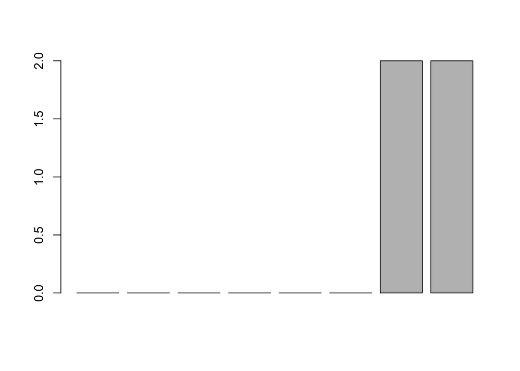

```r
covtruthlist=list(2*c$covmat)
barplot(diag(covtruthlist[[1]]))
```

```r
A="truth"
compute.hm.train.log.lik.pen.with.L(train.b = w[index,],se.train = se,covmat = covtruthlist,A = A,pen = 1,L = L[-1,])
```

```r
likmattruth=t(as.matrix(readRDS("liketraintruth.rds")))
LSigL=lapply(covtruthlist,function(x){L[-1,]%*%x%*%t(L[-1,])})

lltest=log.lik.func(b.mle=w[j,],V.gp.hat = L[-1,]%*%diag(se[j,])^2%*%t(L[-1,]),covmat =LSigL )

identical(as.numeric(likmattruth[j]),as.numeric(lltest))
```

```
## [1] TRUE
```

```r
sum(log(exp(likmattruth)))
```

```
## [1] -9556.766
```

```r
sum(log(exp(likmattruth[1:1000])))
```

```
## [1] -9556.766
```

```r
weightedquants=lapply(seq(1:nrow(w)),function(j){total.quant.per.snp.no.baseline(j,covtruthlist,b.gp.hat=w,se.gp.hat = se,pis,A=A,checkpoint = FALSE,L=L[-1,])})

w=data.frame(wfull[,-1])
a=post.mean.with.proj(b.mle = t(w[1,]),tinv = solve(L[-1,]%*%diag(se[1,],R)%*%t(L[-1,])+L[-1,]%*%covtruthlist[[1]]%*%t(L[-1,])),U.k = covtruthlist[[1]],L=L[-1,])
mashnobasemeans=read.table("truthposterior.means.txt")[,-1]
all.equal(as.numeric(mashnobasemeans[1,]),as.numeric(a))
```

```
## [1] TRUE
```

```r
##Let's try with mash truth##
pis=1
A="mashtruth"
weightedquants=lapply(seq(1:nrow(w)),function(j){total.quant.per.snp.no.baseline(j,covtruthlist,b.gp.hat=wfull,se.gp.hat = se,pis,A=A,checkpoint = FALSE,L=diag(1,R))})
a=post.mean.with.proj(b.mle = wfull[1,],tinv = solve(diag(se[1,])+covtruthlist[[1]]),U.k = covtruthlist[[1]],L=diag(1,R))
mashtruth=read.table("mashtruthposterior.means.txt")[,-1]
all.equal(as.numeric(mashtruth[1,]),as.numeric(a))
```

```
## [1] TRUE
```

```r
liked=t(as.matrix(readRDS("liketrainwithoneKandoneomeganewwithnoscale.rds")))



sum(log(exp(liked)))
```

```
## [1] -9553.341
```

```r
sum(log(exp(liked[1:1000])))
```

```
## [1] -9553.341
```

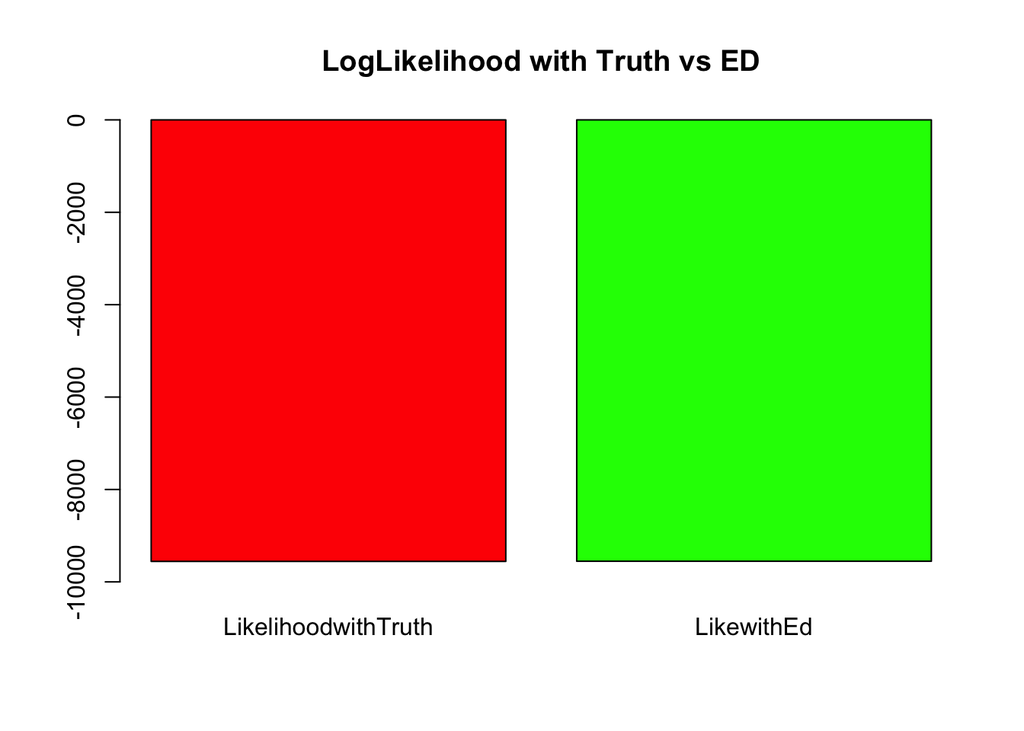

```r
liktable=c(LikelihoodwithTruth=sum(log(exp(likmattruth))),LikewithEd=sum(log(exp(liked))))
barplot(liktable,ylim=c(-10000,0),main="LogLikelihood with Truth vs ED",col=c("red","green"))
```

### Now there is just one component for MASH, using the centered t and beta hats to compute likelihood:

We use the same data as above (i.e., there is a mean) and we center the chats and t statistics before training and computing likelihood:

```r
rm(list=ls())

c=readRDS("chatfixedomega.rds")
t=c$t;b=c$chat;se=c$shat
length(which(rowSums(c$beta)!=0))
```

```
## [1] 1000
```

```r
###Here we're just going to use the 'real associations'
index=which(rowSums(c$beta)!=0)
t=c$t[index,];b=c$chat[index,];se=c$shat[index,]
R=ncol(t)
##center the estimates
L=diag(R)-1/R*as.vector(rep(1,R))%*%t(as.vector(rep(1,R)))
w=t(L%*%t(b))
wt=t(L%*%t(t))

dim(t)
```

```
## [1] 1000    8
```

```r
identical(t,b)
```

```
## [1] TRUE
```

```r
strongt=wt[index,]
v.j=se



init.cov.list=list()
init.cov.list[[1]]=cov(strongt)

#head(init.cov.list)
mean.mat=matrix(rep(0,ncol(strongt)*nrow(strongt)),ncol=ncol(strongt),nrow=nrow(strongt))
ydata= strongt##train on the max like estimates (same as using max ws)
xamp=1
xcovar=init.cov.list
fixmean=TRUE
ycovar=v.j
xmean=mean.mat
projection=list();for(l in 1:nrow(strongt)){projection[[l]]=diag(1,R)}##no projection in mash
e=extreme_deconvolution(ydata=ydata,ycovar=ycovar,xamp=xamp,xmean=xmean,xcovar=init.cov.list,fixmean=T,projection=projection)##notice no projection.
se.train=se



se.train=se


covlist=e$xcovar

train.b=data.frame(strongt);se.train = se;covmat = covlist;pen = 1;L = diag(1,R);J=nrow(train.b)
lik.mat=t(sapply(seq(1:J),function(j){
  V.gp.hat=diag(se.train[j,])^2;
  b.mle=train.b[j,]
  dmvnorm(x=b.mle, sigma=(covlist[[1]]+V.gp.hat),log=TRUE)}))##here the likelihood estimate is different

dim(lik.mat)
```

```
## [1]    1 1000
```

```r
sum(log(exp(lik.mat)))
```

```
## [1] -11512
```

```r
j=10
lik.mat[10]
```

```
## [1] -8.696133
```

```r
V.gp.hat=diag(se.train[j,])^2;
dmvnorm(x=train.b[j,], sigma=(covlist[[1]]+V.gp.hat),log=TRUE)
```

```
##        10
## -8.696133
```

```r
mean(lik.mat)
```

```
## [1] -11.512
```

```r
e$avgloglikedata
```

```
## [1] -11.512
```

```r
A="mash"
compute.hm.train.log.lik.pen.with.L(train.b = w[index,],se.train = se,covmat = covlist,A = A,pen = 1,L = diag(1,R))
```

```r
lik.mat=readRDS(paste0("liketrain",A,".rds"))
sum(log(exp(lik.mat)))
```

```
## [1] -11512
```

```r
pis=1
A="mash"

weightedquants=lapply(seq(1:nrow(w)),function(j){total.quant.per.snp(j,covlist,b.gp.hat=w,se.gp.hat = se,pis,A=A,checkpoint = FALSE)})
```

Let’s compare RMSEs:

```r
mash.means=read.table("mashposterior.means.txt")[,-1]
mash.nobasemeans=read.table("mashnobedcovposterior.means.txt")[,-1]
mash.nobtruth=read.table("truthposterior.means.txt")[,-1]
mash.truth=read.table("mashtruthposterior.means.txt")[,-1]
beta=as.matrix(c$beta)
mle=as.matrix(w)
mash.means=as.matrix(mash.means)
standard=sqrt(mean((beta-mle)^2))

rmse.mash=sqrt(mean((mash.means-beta)^2))/standard
rmse.mnb=sqrt(mean((mash.nobasemeans-beta)^2))/standard
rmse.truth=sqrt(mean((mash.nobtruth-beta)^2))/standard
rmse.mashtruth=sqrt(mean((mash.truth-beta)^2))/standard
rmse.all.table=cbind(mash=rmse.mash,mnb=rmse.mnb)

rmse.mash
```

```
## [1] 0.4707204
```

```r
rmse.mnb
```

```
## [1] 0.4707204
```

```r
rmse.truth
```

```
## [1] 0.3595063
```

```r
rmse.mashtruth
```

```
## [1] 0.3762791
```

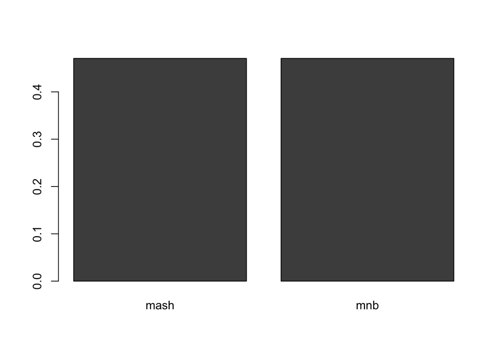

```r
barplot(rmse.all.table)
```

```r
U.gp1kl = post.b.gpkl.cov(V.gp.hat.inv = solve(diag(se[1,],R)),U.0k.l = covlist[[1]])

all.equal(as.numeric(post.b.gpkl.mean(b.mle = w[1,],V.gp.hat.inv = solve(diag(se[1,],R)),U.gp1kl = U.gp1kl)),as.numeric(mash.means[1,]))
```

```
## [1] TRUE
```

We should also compute the likelihood with *MASH* using the truth:

```r
c=readRDS("chatfixedomega.rds")
t=c$t;b=c$chat;se=c$shat
length(which(rowSums(c$beta)!=0))
```

```
## [1] 1000
```

```r
###Here we're just going to use the 'real associations'
index=which(rowSums(c$beta)!=0)
t=c$t[index,];b=c$chat[index,];se=c$shat[index,]
R=ncol(t)
##center the estimates
L=diag(R)-1/R*as.vector(rep(1,R))%*%t(as.vector(rep(1,R)))
w=t(L%*%t(b))
wt=t(L%*%t(t))

dim(t)
```

```
## [1] 1000    8
```

```r
identical(t,b)
```

```
## [1] TRUE
```

```r
strongt=wt[index,]
v.j=se



covtruthlist=list(2*c$covmat)
A="truthmash"
compute.hm.train.log.lik.pen(train.b = w[index,],se.train = se,covmat = covtruthlist,A = A,pen = 1)
```

```r
likmattruth=t(as.matrix(readRDS("liketraintruthmash.rds")))


j=10
lltest=log.lik.func(b.mle=w[j,],V.gp.hat =diag(se[j,])^2,covmat =covtruthlist)

identical(as.numeric(likmattruth[j]),as.numeric(lltest))
```

```
## [1] TRUE
```

```r
sum(log(exp(likmattruth)))
```

```
## [1] -11926.56
```

```r
sum(log(exp(likmattruth[1:1000])))
```

```
## [1] -11926.56
```

```r
train.b=data.frame(w);se.train = se;covmat = covtruthlist;pen = 1;L = diag(1,R);J=nrow(train.b)
lik.mat=t(sapply(seq(1:J),function(j){
  V.gp.hat=diag(se.train[j,])^2;
  b.mle=train.b[j,]
  dmvnorm(x=b.mle, sigma=(covtruthlist[[1]]+V.gp.hat),log=TRUE)}))##here the likelihood estimate is different

dim(lik.mat)
```

```
## [1]    1 1000
```

```r
sum(log(exp(lik.mat)))
```

```
## [1] -11926.56
```

```r
j=10
lik.mat[10]
```

```
## [1] -8.764083
```

```r
V.gp.hat=diag(se.train[j,])^2;
dmvnorm(x=train.b[j,], sigma=(covtruthlist[[1]]+V.gp.hat),log=TRUE)
```

```
##        10
## -8.764083
```

```r
mean(lik.mat)
```

```
## [1] -11.92656
```